# Taller 6

Métodos Computacionales para Políticas Públicas - URosario

**Entrega: viernes 31-mar-2017 11:59 PM**

**[David Valles]**  
[david.valles@urosario.edu.co]

## Instrucciones:

- Guarde una copia de este *Jupyter Notebook* en su computador, idealmente en una carpeta destinada al material del curso.
- Modifique el nombre del archivo del *notebook*, agregando al final un guión inferior y su nombre y apellido, separados estos últimos por otro guión inferior. Por ejemplo, mi *notebook* se llamaría: mcpp_taller6_santiago_matallana
- Marque el *notebook* con su nombre y e-mail en el bloque verde arriba. Reemplace el texto "[Su nombre acá]" con su nombre y apellido. Similar para su e-mail.
- Desarrolle la totalidad del taller sobre este *notebook*, insertando las celdas que sea necesario debajo de cada pregunta. Haga buen uso de las celdas para código y de las celdas tipo *markdown* según el caso.
- Recuerde salvar periódicamente sus avances.
- Cuando termine el taller:
  1. Descárguelo en PDF. Si tiene algún problema con la conversión, descárguelo en HTML.
  2. Suba todos los archivos a su repositorio en GitHub, en una carpeta destinada exclusivamente para este taller, antes de la fecha y hora límites.

(Todos los ejercicios tienen el mismo valor.)

### Resuelva la parte 1 de [este documento](http://www.math.pitt.edu/~sussmanm/3040Summer14/exercisesII.pdf).

```python
import numpy as np
import scipy.linalg as la
import matplotlib.pyplot as plt
```

```python
#1
x=2
#2
def cuadrado (a):
    y=a**2
    print (y)
cuadrado (x)

def cubo (a):
    y=a**3
    print (y)
cubo (x)
```

```
4
8
```

```python
#3
theta= 45
#4
np.sin(theta)
```

```
0.85090352453411844
```

```python
np.cos(theta)
#el angulo theta fue definido en grados, en radianes seria apartir de pi veces el radio de una circunferencia.
```

```
0.52532198881772973
```

```python
#5
meshPoints = np.linspace(-1,1, 500)
print(meshPoints)
```

[output not shown]

[output cut: 29 more lines]

[output not shown]

```python
#6
#como esta en base 0 el 52 toma la posición 53
meshPoints[52]
```

```
-0.79158316633266534
```

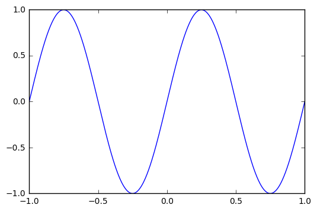

```python
#7
import math
pi= math.pi
%matplotlib inline
plt.plot(meshPoints,np.sin(2* pi *meshPoints))
```

### Resuelva los ejercicios de las secciones 4.1, 5.1, 6.1, 7.4 y 8.5 de [este documento](http://www.python-academy.com/download/pycon2012/matplotlib_handout.pdf).

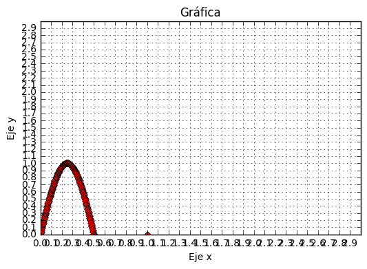

```python
#4.1
#1. Plot a simple graph of a sinus function in the range 0 to 3 with a step size of 0.01.
#2. Make the line red. Add diamond-shaped markers with size of 5.
#3. Add a legend and a grid to the plot.
plt.title("Gráfica")
plt.xlabel("Eje x")
plt.ylabel("Eje y")
plt.grid()
plt.xlim(0, 3)
plt.ylim(0, 3)
plt.xticks(np.arange(0, 3, 0.1))
plt.yticks(np.arange(0, 3, 0.1))
plt.plot(meshPoints,np.sin(2* pi *meshPoints), "rD",markersize=5)
#Dado el rango tan ampli0 y el step size tan pequeño no son claros los puntos de los ejes,
#ni la forma de de diamante de los marcadores
```

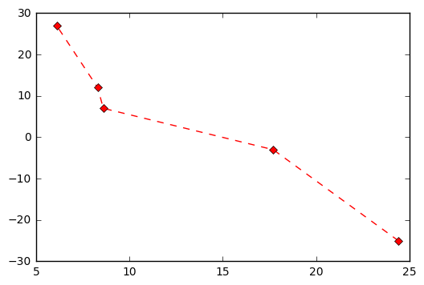

```python
#5.1
#Apply different line styles to a plot. Change line color and thickness as well as the size and the kind of
#the marker. Experiment with different styles.
x = [24.4, 17.7, 8.6, 8.3, 6.1]
y = [-25,-3,7,12,27]
plt.plot(x,y, "r--D",markersize=5)
```

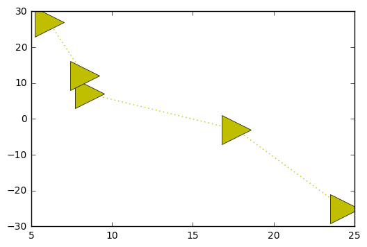

```python
plt.plot(x,y, "y:>",markersize=30)
```

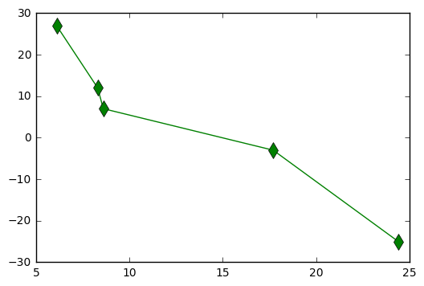

```python
plt.plot(x,y, "g-d",markersize=10)
```

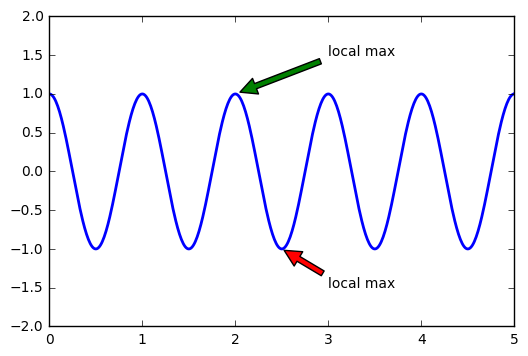

```python
#6.1
#Annotate a line at two places with text. Use green and red arrows and align it according to figure
# points and data.
fig = plt.figure()
ax = fig.add_subplot(111)

t = np.arange(0.0, 5.0, 0.01)
s = np.cos(2*np.pi*t)
line, = ax.plot(t, s, lw=2)

ax.annotate('local max', xy=(2, 1), xytext=(3, 1.5),
            arrowprops=dict(facecolor='green', shrink=0.05),
            )
ax.annotate('local max', xy=(2.5, -1), xytext=(3, -1.5),
            arrowprops=dict(facecolor='red', shrink=0.05),
            )

ax.set_ylim(-2,2)
plt.show()
```

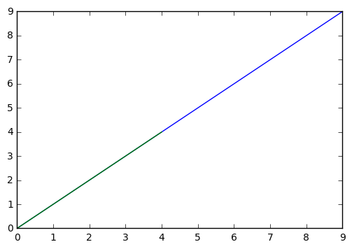

```python
#8.5
#1. Draw two figures, one 5 by 5, one 10 by 10 inches.
#2. Add four subplots to one figure. Add labels and ticks only to the outermost axes.
#3. Place a small plot in one bigger plot.
plt.plot(range(10))
plt.plot(range(5))
```

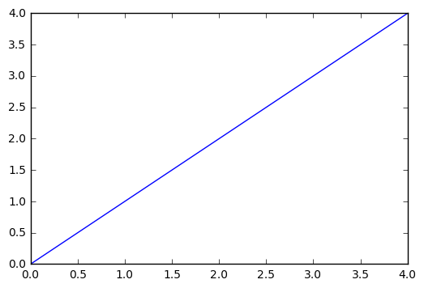

```python
plt.plot(range(5))
```